| Beaver Lake | Broome County Beaver Lake Assn. | Town(s) of Windsor | Broome County |
| --- | --- | --- | --- |

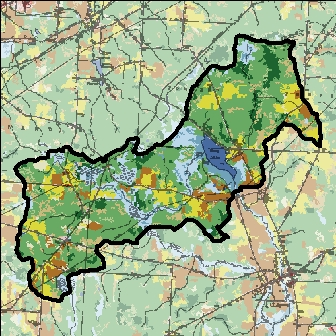

## Beaver Lake – 2018 Sampling Season Results

Open Water Indicators

2018 Sampling Results

Seasonal Change

Season Avg

Decadal Average

Decadal Trend?

Longterm Avg

Longterm Trend?

06-10

06-24

07-08

07-22

08-05

08-20

09-02

09-16

Clarity (m)

2.1

1.4

1.6

1.4

2

0.7

1.3

2

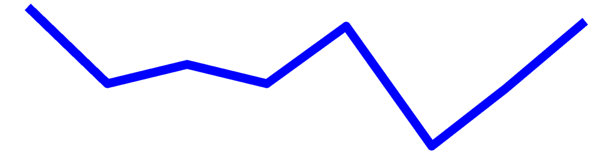

1.5

2.1

2

Surface TP (mg/L)

0.025

0.042

0.028

0.04

0.028

0.036

0.012

0.024

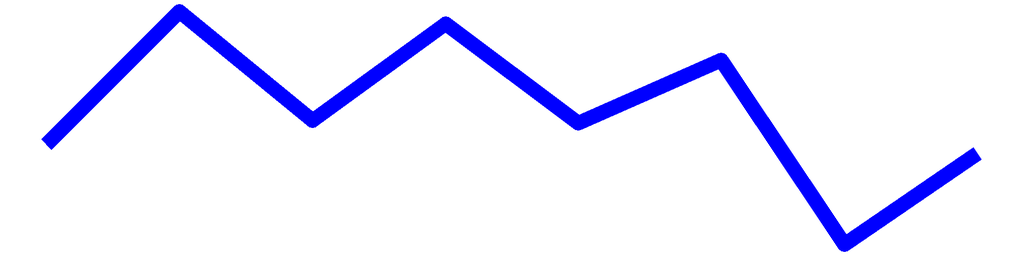

0.029

0.029

0.028

Surface TDP (mg/L)

0.01

0.016

0.014

0.007

0.016

0.03

0.006

0.009

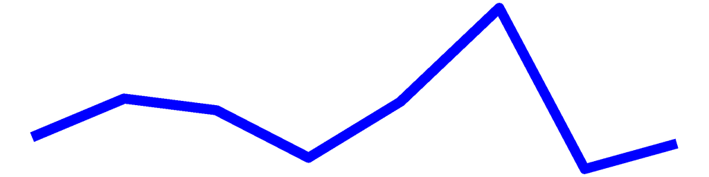

0.014

TN (mg/L)

0.431

0.463

0.545

0.698

0.487

0.489

0.398

0.55

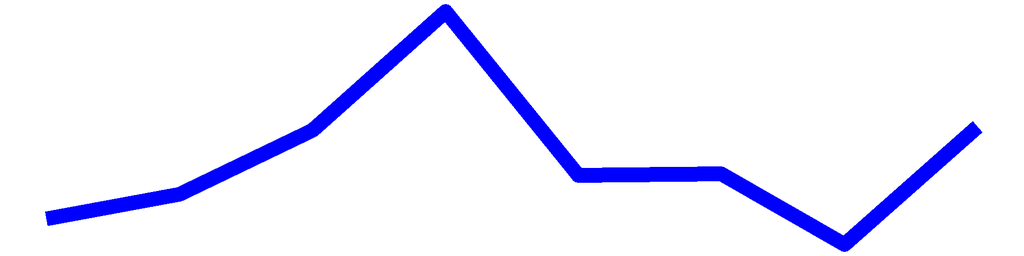

0.508

0.569

0.498

TDN (mg/L)

0.427

0.418

0.46

0.611

0.478

0.446

0.343

0.495

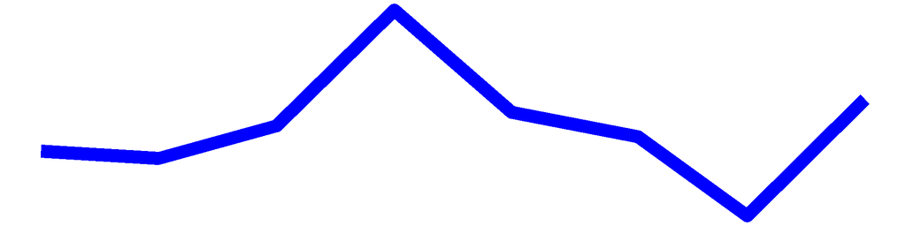

0.46

0.343

0.343

TN:TP

17

11

20

17

18

14

33

23

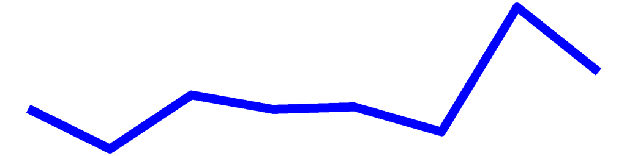

20

22

20

Surface NH3 (mg/L)

0.024

0.015

0.032

0.103

0.042

0.052

0.013

0.029

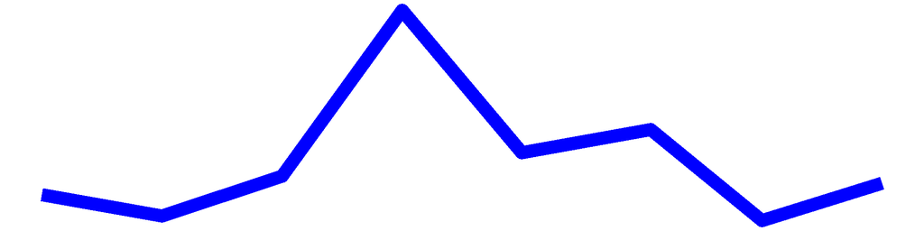

0.039

0.037

0.036

Chl.a (ug/L)

12.8

12.1

18.5

19.9

6.9

127.7

22.7

4.1

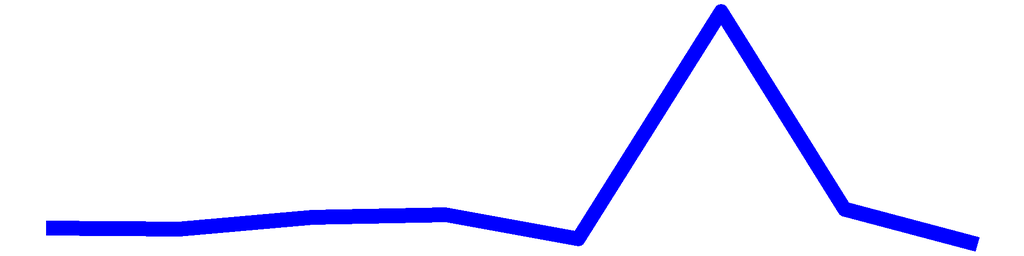

28.1

20.4

22.5

pH

6.5

7

8.8

7.6

7.2

6.5

7.2

7.6

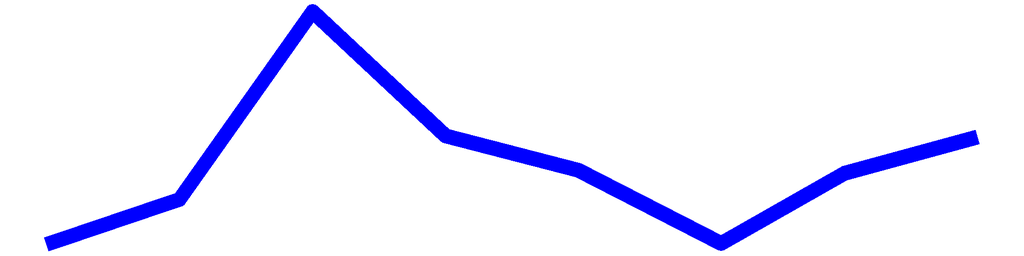

7.3

7.4

7.3

Cond (umho/cm)

34

39

36

39

27

29

26

36

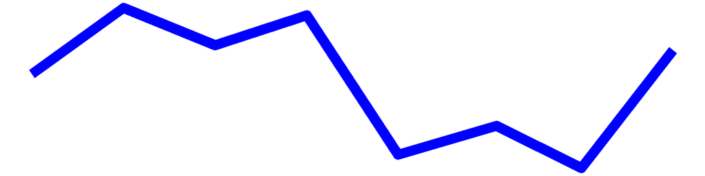

33

50

52

Surface Chloride (mg/L)

5

5

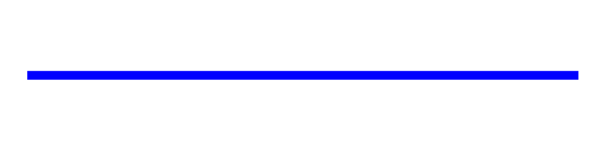

5

6

6

Upper Temp (degC)

20

23

27

23

26

23

23

22

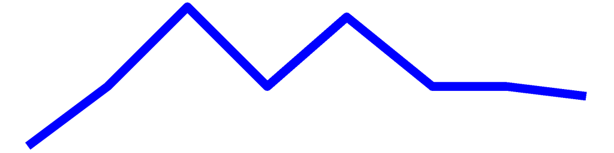

24

23

22

FP BG Chl.a (ug/L)

0

2

11.8

0.3

0.1

6.7

4.4

1.9

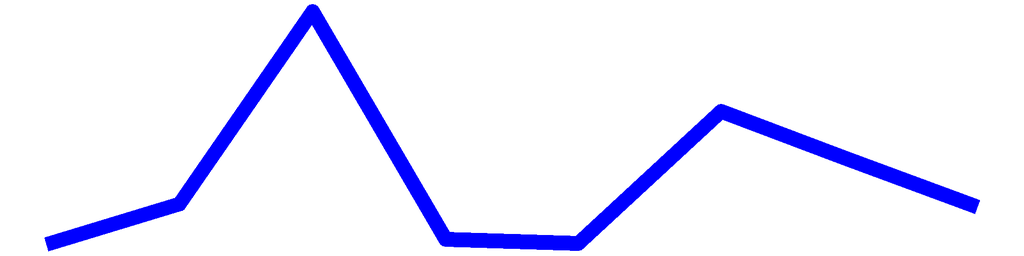

3.4

8.9

8.9

### NYHABs notifications

#### Were there any reported HABs this season? **Yes.**

| Date of First Listing | Date of Last Listing | Number of Reports |
| --- | --- | --- |
| 07/08/2018 | 09/16/2018 | 35 |

### Shoreline HAB Sample Dates 2018

| HAB Indicators | Criteria | 07-08 | 07-23 | 08-20 | 09-02 | 09-16 |
| --- | --- | --- | --- | --- | --- | --- |
| FP BGA Chl. a | 25 ug/L | 17107.25 | 657.06 | 25.32 | 463.06 | 69.46 |
| Microcystin | 20 ug/L | ND | ND | ND | ND | ND |
| Microscopy | Dominant | Unicellular colonial coccoid green algae | Anabaena, Dolichospermum | Dolichospermum | Coelastrum, Planktothrix | Anabaena |

### HABs Status

#### Open Water Algae

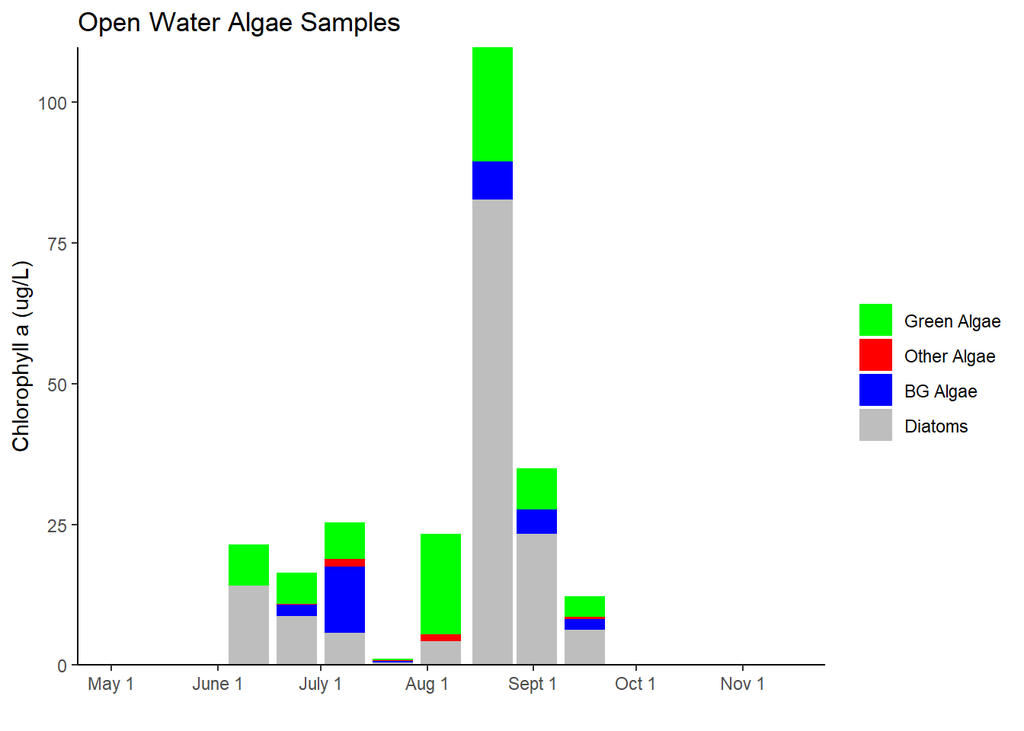

#### Shoreline Algae

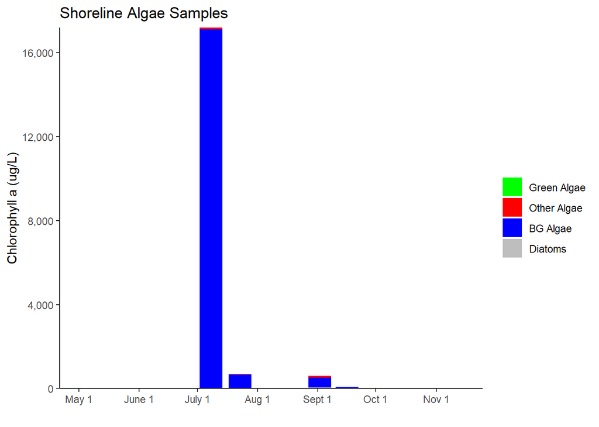

## Beaver Lake Long-Term Trend Analysis

#### Clarity

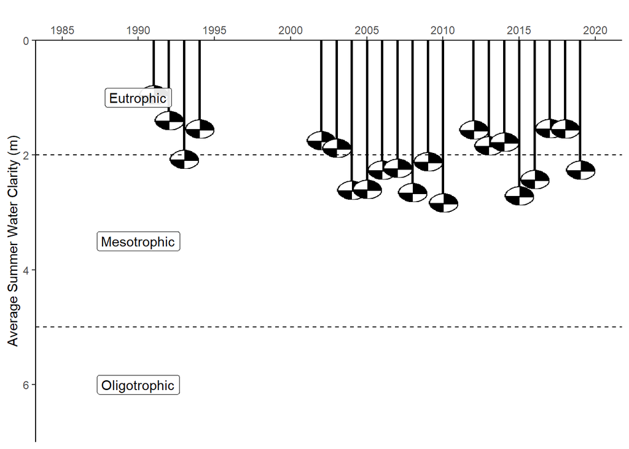

#### Chlorophyll *a*

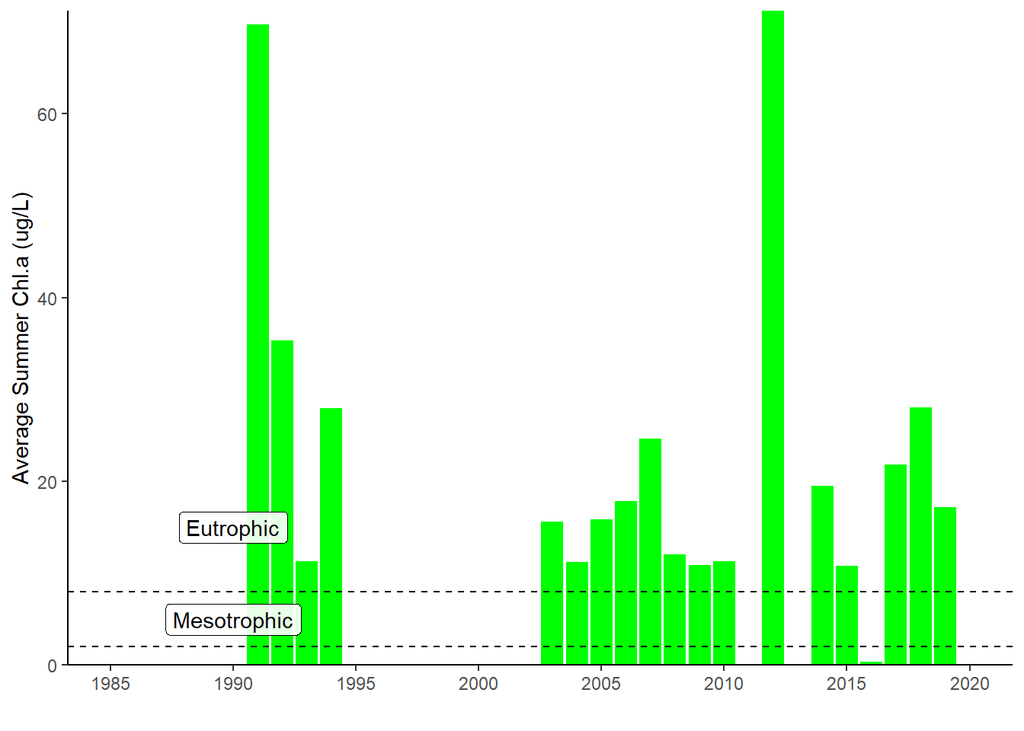

#### Surface and Deep Phosphorus

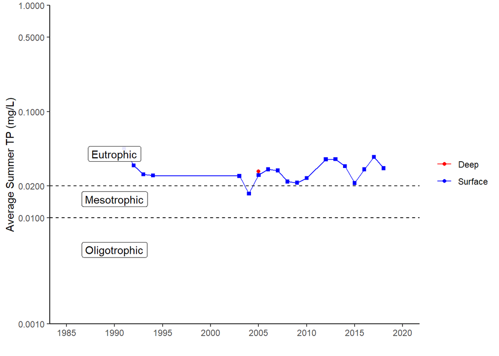

#### Nitrogen

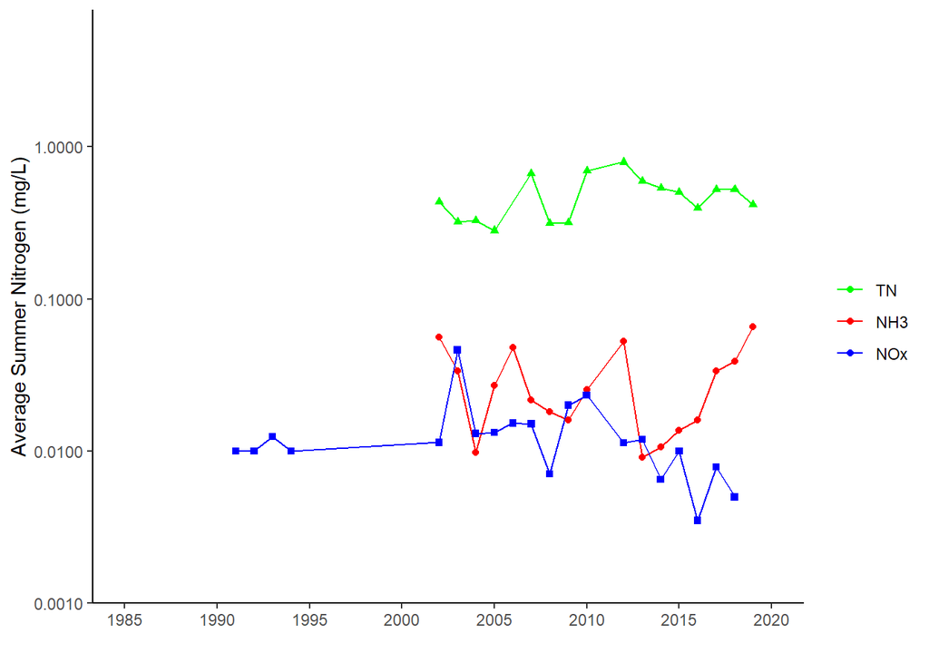

#### TN : TP

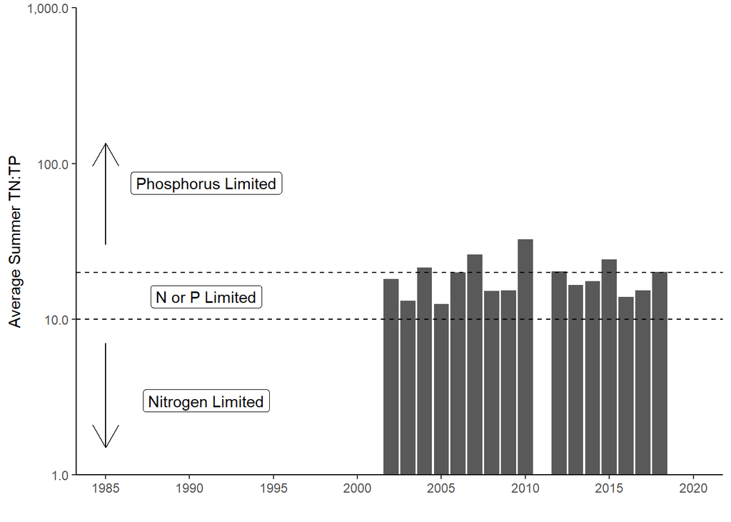

#### pH

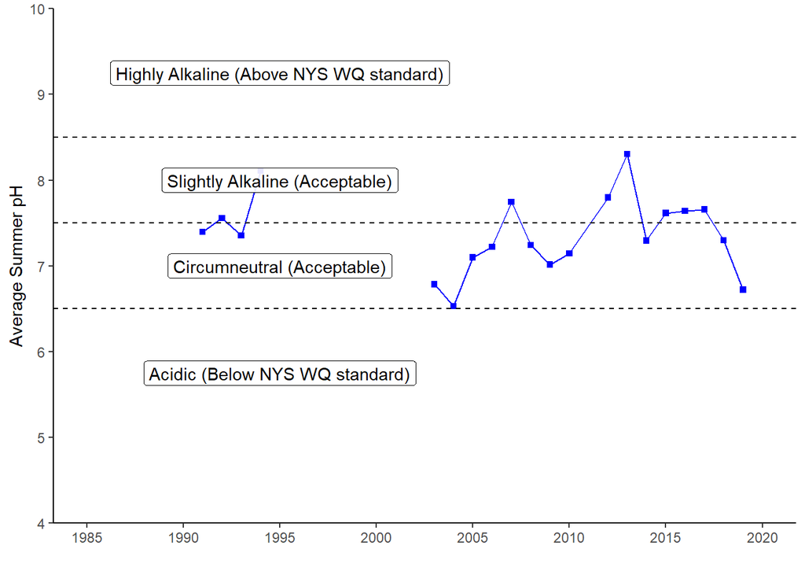

#### Specific Conductance

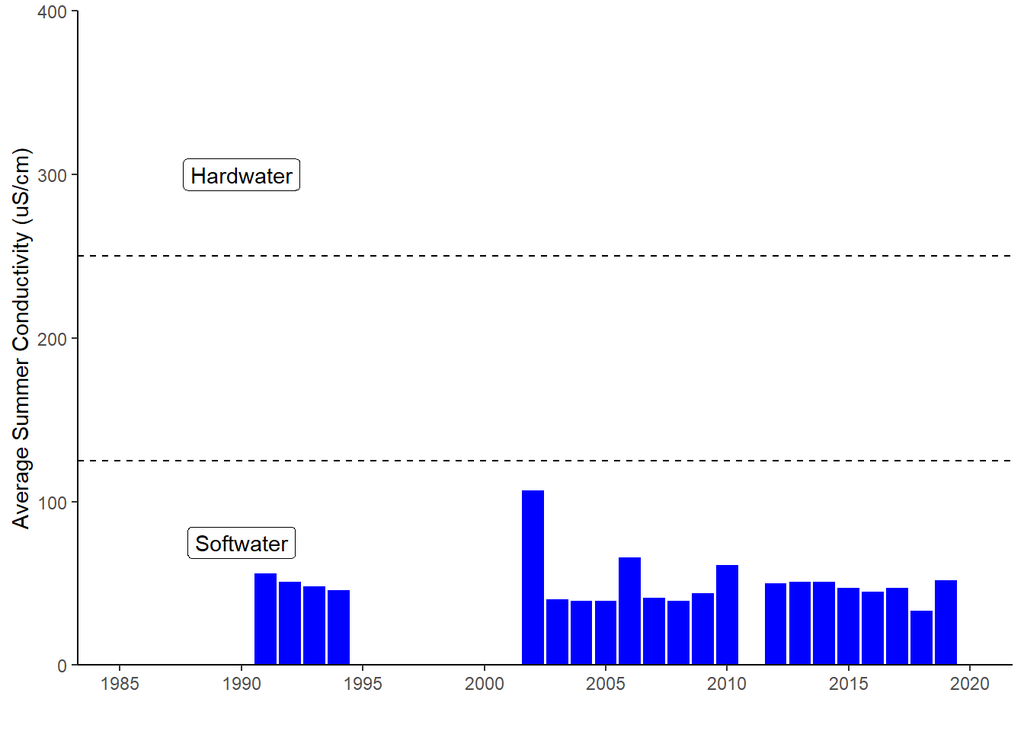

#### Calcium

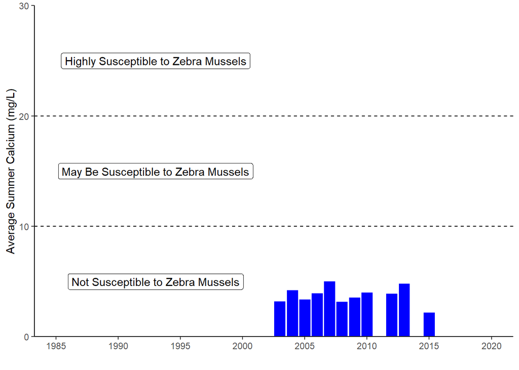

#### Chloride

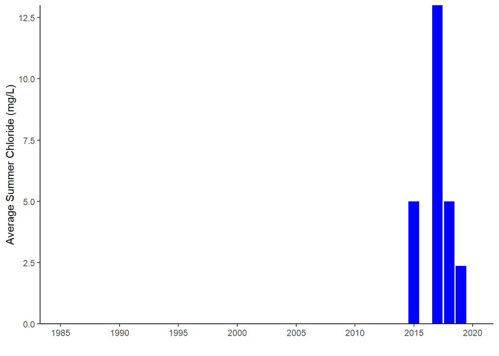

#### Color

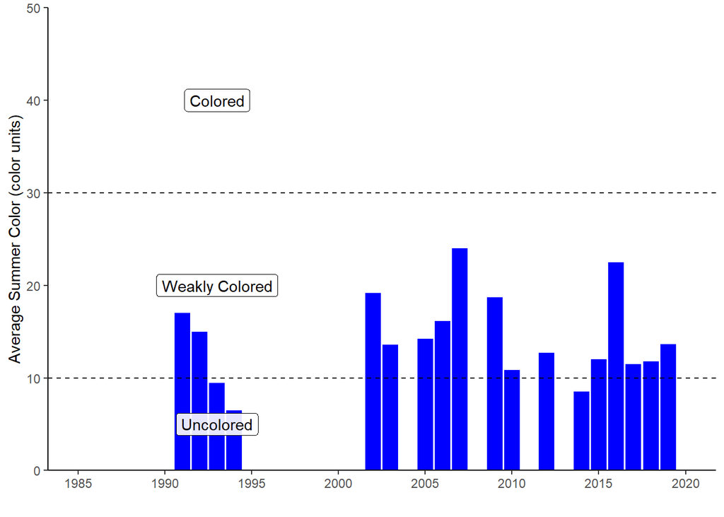

#### Surface and Deep Temperature

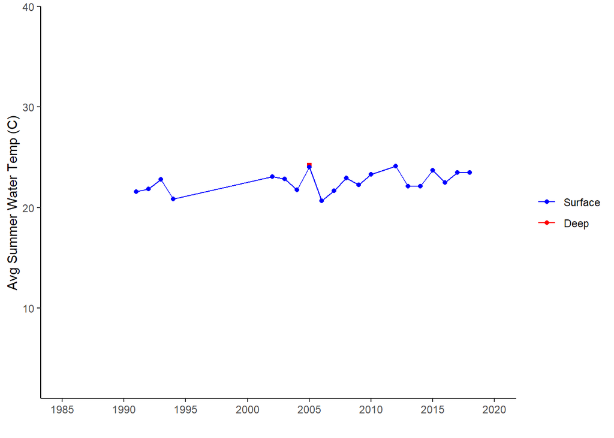

#### Lake Perception

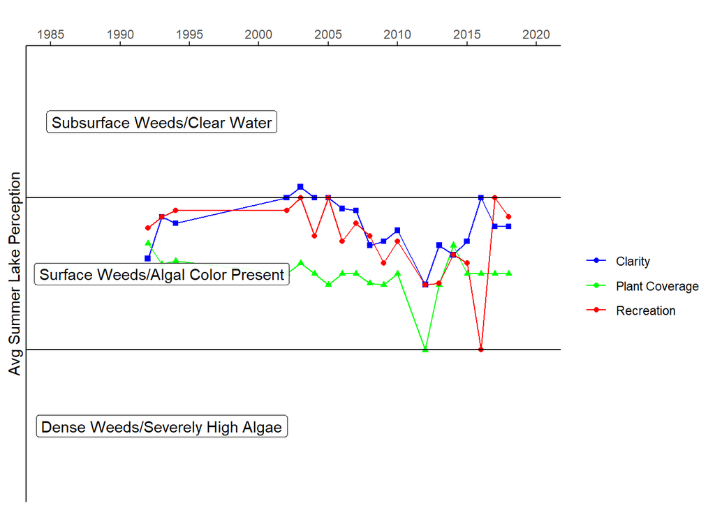

## Beaver Lake - In-Season Analysis

#### In Season Water Clarity

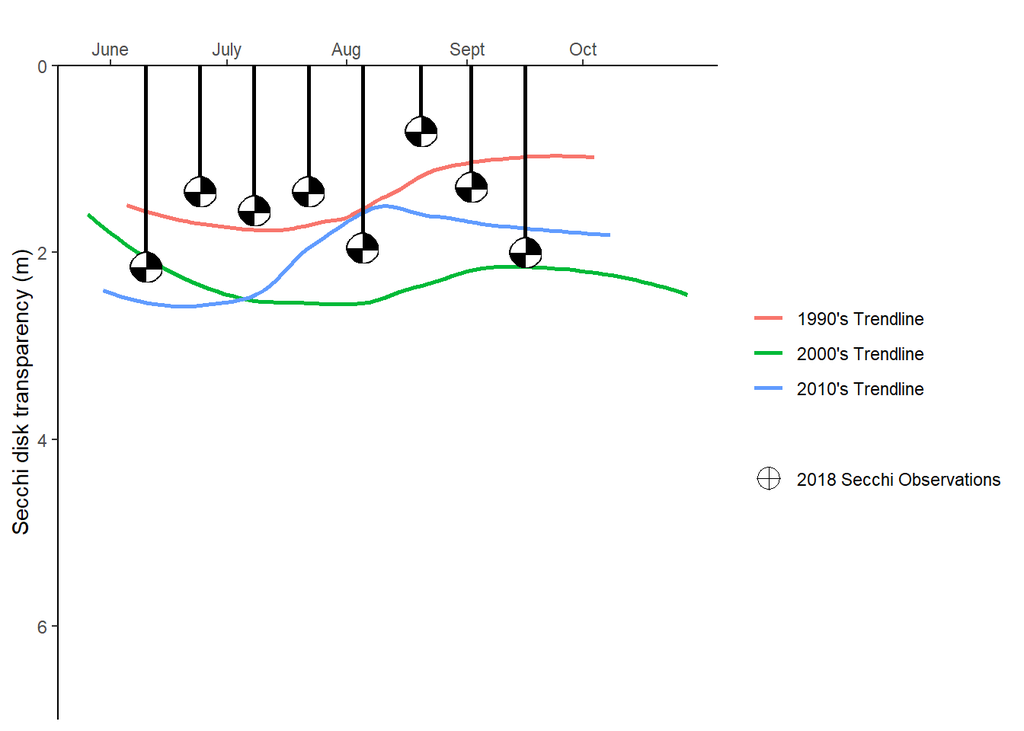

#### In Season Water Temperature

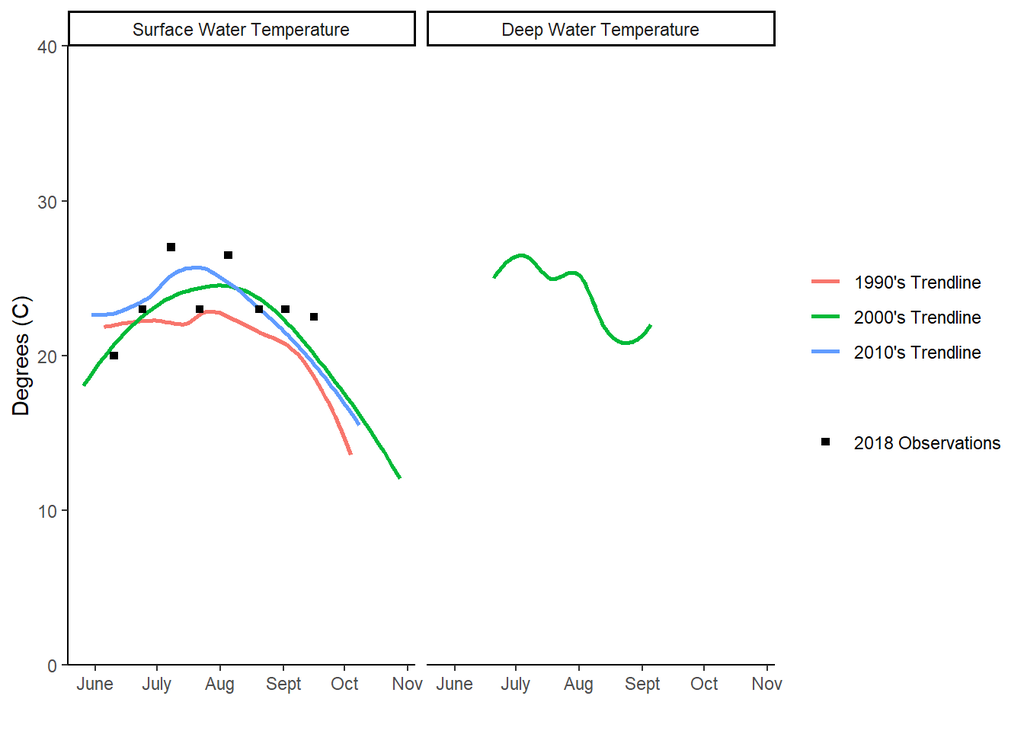

### Beaver Lake – Lake Scorecard

```
## [1] 1
```

[output not shown]

| Aquatic Invasive Species | Present |
| --- | --- |